# Lateral force processing

This notebook opens an image with lateral force data and separates friction from topography effects. Friction turns the tip the opposite way in the forward and backward scans, so it shows in the difference of the two. What both have in common, such as slopes of the surface, shows in their mean. Run it from this folder, next to `SBS-PMMA.nid`.

```python
from NSFopen.process import process

import matplotlib.pyplot as plt
```

```python
afm = process("SBS-PMMA.nid")
print(afm.channels["Forward"])
channel = "Friction force"
```

```
['Deflection', 'Z-Axis', 'Friction force', 'Z-Axis Sensor']
```

## The offset between the scans

The forward and backward images lie a few pixels apart. It is best measured on the height, which should be the same in both scans. `find_shift` returns the shift in pixels and how well the images match, 1 being a perfect match.

```python
shift_x, shift_y, match = afm.find_shift(("Forward", "Z-Axis"), ("Backward", "Z-Axis"))
print(f"The backward scan lies {shift_x:.2f} pixels to the side and {shift_y:.2f} lines up, match {match:.2f}")
```

```
The backward scan lies 3.75 pixels to the side and 0.04 lines up, match 0.97
```

## Friction and mean

`combine` shifts the backward scan by that amount and stores each result as a new channel, with the unit of the original. Only the shift along the scan line is used. `half_diff` is (forward - backward) / 2. The outermost columns have no partner in the other scan after the shift, so ignore a few pixels at the left and right edges.

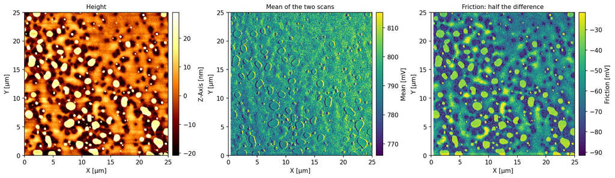

```python
forward, backward = ("Forward", channel), ("Backward", channel)
afm.combine(forward, backward, "half_diff", shift_x=shift_x, name="Friction")
afm.combine(forward, backward, "mean", shift_x=shift_x, name="Mean")

fig, axes = plt.subplots(1, 3, figsize=(14, 4.2), layout="constrained", dpi=150)
afm.flatten()
afm.image(ax=axes[0], color_range="p1", title="Height")
afm.image(ax=axes[1], channel="Mean", cmap="viridis", color_range="p1", title="Mean of the two scans")
afm.image(ax=axes[2], channel="Friction", cmap="viridis", color_range="p1", title="Friction: half the difference")
plt.show()
```

The new channels work like any other, for example for the distribution of friction, which separates the two polymers.

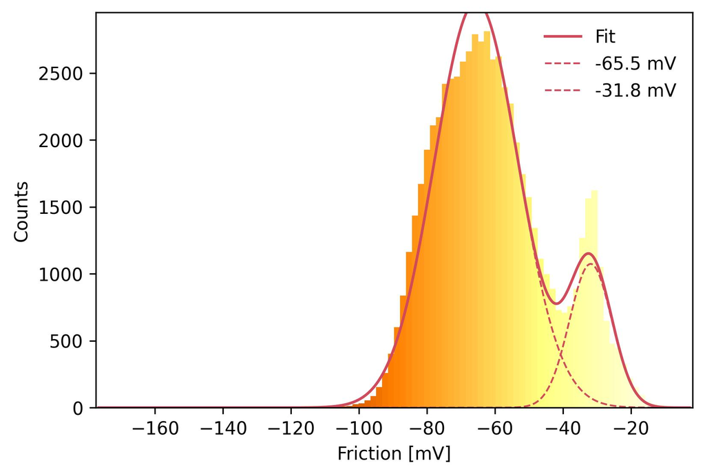

```
2 Gaussians, reduced χ² 17
1: center -65.49 ± 0.071 mV, σ 12.33 ± 0.048, FWHM 29.03, share 82.7 %
2: center -31.81 ± 0.097 mV, σ 6.238 ± 0.079, FWHM 14.69, share 14.8 %
separation 33.68 ± 0.12 mV
```

```python
fig = afm.plot_histogram_fit(channel="Friction", model="gauss2")
plt.show()

fit = afm.histogram_fit(channel="Friction", model="gauss2")
print(fit.summary(1e3, "mV"))
```